# 動物實驗規劃與執行

從理想設計、現實限制到有依據的科學決策

陳敬元 Jing-Yuan Chen, DVM, PhD

jychen@niar.org.tw

國家生物模式中心 (National Center for Biomodels)  
國家實驗研究院 (National Institute of Applied Research)

June 30, 2026

## 串連昨天的課程

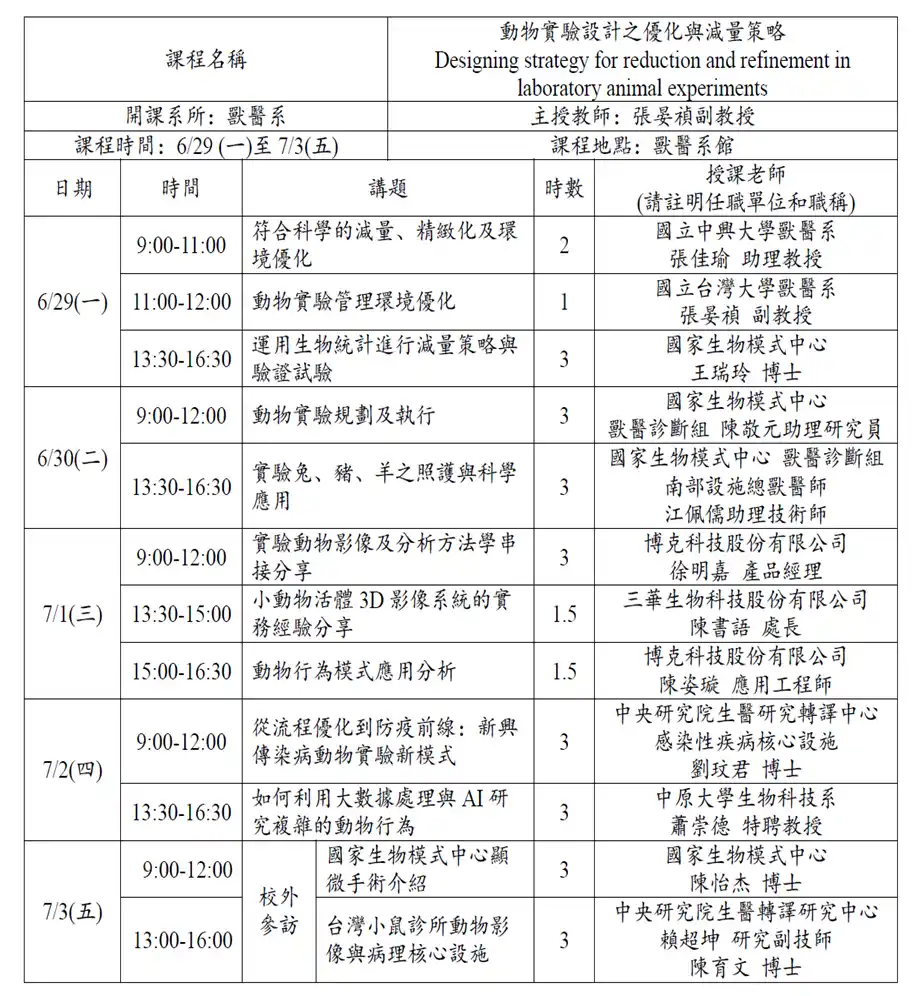

115暑期課程

- 前一天談了
  - **實驗動物 3R**
  - **環境優化**
  - **生物統計**
- 今天介紹的是：
  - 如何把這些原則組合成一個 **真正能執行也能誠實解釋** 的動物實驗。

## 今天由五個問題下手

1. 為什麼一定使用這個物種？
2. 真正的 `experimental unit` 是什麼？
3. 現實限制改變了哪些研究問題？
4. *p*-value 支持的是哪一層推論？
5. 使用每一隻動物，究竟取得了多少可信資訊？

## 本日課程大綱

| 時間 | 主題 |
| --- | --- |
| 09:00–09:35 | 從原則到可執行的研究設計 |
| 09:35–10:20 | 為什麼 PaBV 研究需要鸚鵡？ |
| 10:20–10:30 | 休息 |
| 10:30–11:10 | 從鳥到 cell：有效資訊與 replication |
| 11:10–11:35 | *p*-value、資料判讀與推論界線 |
| 11:35–12:00 | 理想設計、現實限制與執行紀錄 |

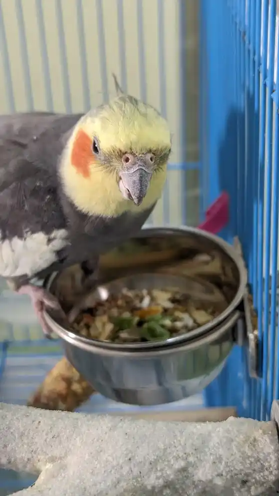

## 為什麼好的動物實驗仍可能失敗？

即使研究已經：

- 通過倫理審查
- 使用適當統計方法
- 完成動物照護與環境控制

結果仍可能因為 **model、design、execution 或 interpretation** 而不可靠。

## 顯著結果不一定是可信結果

*p*-value 不會替我們檢查實驗設計，即使 `*p* < 0.05`，仍需確認：

- **分析單位正確嗎？**  
  experimental unit 是否被當成真正的 `n`？
- **組間差異能歸因於 treatment 嗎？**  
  randomization、blinding 與 confounding 是否妥善處理？
- **分析決策是事先定義的嗎？**  
  endpoint、排除規則與分析方法是否看到結果後才改變？

## 沒有 RCT，就代表沒有合理證據嗎？

BMJ 2003

- 找不到比較「背降落傘」與「不背降落傘」的 randomized controlled trial。
- 沒有 randomized controlled trial，就不能判斷降落傘有用嗎？

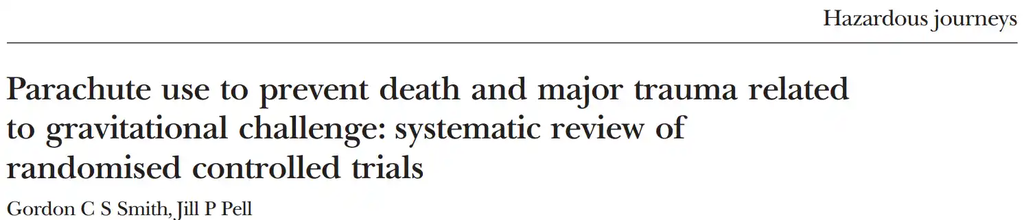

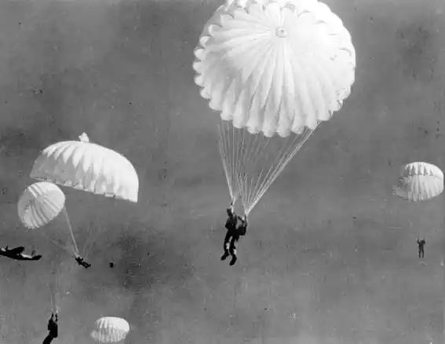

Smith & Pell. *BMJ*. 2003;327:1459–1461. [doi:10.1136/bmj.327.7429.1459](https://doi.org/10.1136/bmj.327.7429.1459)

## RCT 做了，但回答的是哪一個情境？

**這個 RCT 的 exposure，是否等於真正想回答的情境？**

**Trial condition**  
高度：0.6 m；速度接近 0 km/h 停在地面的飛機／直升機

**Target condition**  
high altitude；高速墜落

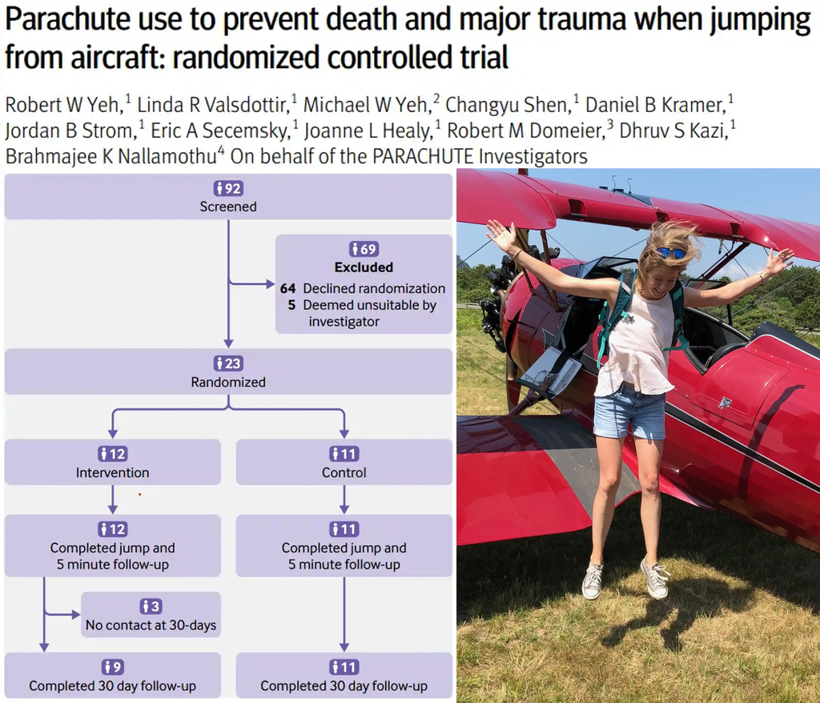

**Important**

**統計與分析都正確，但研究情境沒有代表真正要解答的問題。**

Yeh et al. *BMJ*. 2018;363:k5094. [doi:10.1136/bmj.k5094](https://doi.org/10.1136/bmj.k5094)  
[秦良丰事件](https://www.cna.com.tw/news/aipl/202408280371.aspx)

## Reproducibility 可能在哪裡中斷？

| 階段 | 常見問題 |
| --- | --- |
| Research question | 問題模糊、primary endpoint 未定義 |
| Model | 物種或疾病模型無法代表目標 biology |
| Design | unit、control、randomization、sample size 不適當 |
| Execution | operator、時間、housing、batch 發生 drift |
| Analysis | 忽略 dependence、missing data 或 multiple testing |
| Reporting | 只呈現部分結果，方法不足以重建 |

## 「重複」其實有不同層次

**1 Repeatability**

同一團隊、同一設備、短時間內重做

**2 Within-laboratory reproducibility**

同一實驗室、不同批次或不同人員

**3 Between-laboratory reproducibility**

不同實驗室仍能得到相容結果

**4 External / translational validity**

結果能否延伸至其他條件、物種或臨床情境

**Note**

**`前三層問的是「能否重現」；第四層問的是「能否推廣」。`**

## Technical replication ≠ Biological replication

**`同一隻動物內增加測量`**

- 10 張 tissue sections
- 100 張 images
- 5,000 個 cells
- millions of reads

**`增加 biological replication`** - 需要更多 independent animals

Technical replication 可以提高 measurement precision，  
但不能取代 animal-level biological variation。

## 低 reproducibility 也是動物倫理問題

如果研究因設計或執行問題而無法產生可信知識：

- 動物已承受研究程序
- 經費與時間已投入
- 後續研究可能建立在不可靠結果上
- 其他團隊可能再次使用動物重做

**Important**

**Scientific validity (科學效性) 不是 3R 之外的額外要求；** **是合理使用動物的必要條件。**

## 當理想設計超出現實資源

Power analysis 顯示每組需要 12 隻動物，  
但目前經費與設施只能支持每組 4 隻。

**`合理的作法是什麼？`**

- 1) 先做實驗，得到顯著 *p-value* 就表示設計正確，實驗成功！
- 2) 仍以每組 4 隻執行，維持原本的 confirmatory conclusion
- 3) 增加更多 measurements，補償動物數不足
- 4) 重新評估研究目的：縮小問題、改為 pilot，或暫緩執行

# Part 1｜理論原則 vs 真實研究

## Reduction 不是「越少越好」

**Warning**

- **動物數過多，會造成不必要的 animal harm。**
- **動物數過少、無法回答問題，也無法產生足以支持動物使用的 scientific benefit。**

**Reduction 的目標：**

- 使用足以回答研究問題的最少動物數，同時維持研究的 scientific validity。
- 動物數、研究效度與動物負擔必須一起評估。

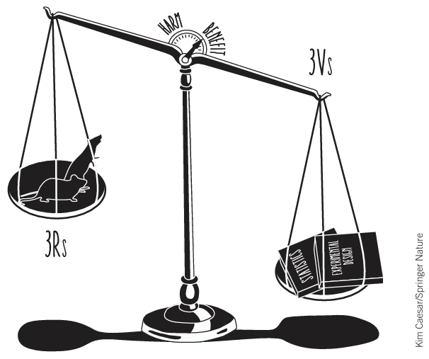

Illustration: Kim Caesars / Springer Nature

## 從研究問題到可執行實驗

[figure not shown]

## 容易取得的動物，不一定是有效模型

**`價格便宜`**

- 能否重現相關 disease biology

**`飼養容易`**

- 是否具有合理的 host susceptibility

**`試劑資源多`**

- endpoint 是否能回答研究問題

**`文獻資源完整`**

- 結果是否具有 biological relevance

**Important**

- **Model availability ≠ model validity**
- **方便，不等於適合。**

## Experimental unit：先追蹤 treatment assignment

**Important**

`Experimental unit` 是能被**獨立分派 treatment** 的最小單位。

**`Treatment → bird`**

- 每隻鳥可被獨立分派 treatment
- **鳥可能是 experimental unit**

**`Treatment → cage`**

- 同一 cage 內動物接受相同 treatment
- **cage 才是 experimental unit**

**`Treatment → room`**

- 整個 room 只有一種 treatment
- **room effect 與 treatment 可能無法分離**

**`判斷原則`**

- 先看 treatment 分派給誰
- 再看哪些觀察值彼此獨立

## Measurement unit 不等於 experimental unit

EU **1 隻鳥** experimental unit

→

M **10 張切片** tissue sections

→

M **100 個視野** microscopic fields

→

M **5,000 個細胞** single-cell observations

→

M **數百萬 reads** sequencing reads

**Important**

- **5,000 個細胞 ≠ 5,000 隻獨立動物**
- measurement unit 增加，不代表 experimental unit 增加。

## 清楚實驗類型，才可以下正確的結論

[figure not shown]

**Important**

- **研究目標不同，結論強度就不同。**
- 不適合把 feasibility 或 exploratory study 包裝成 confirmatory 的正式結論。

## Pilot 不是縮小版 confirmatory study

[figure not shown]

**Important**

- **Pilot studies reduce uncertainty.**
- Pilot 通常不能可靠證明 treatment effect。

## 技術應該服務研究問題

**Warning**

**Technology-first**

先決定使用新技術  
→ 再尋找樣本與研究問題

**可能風險：**

- endpoint 不清楚
- experimental unit 未定義
- replication 與預算不匹配
- 產生大量但難以解釋的資料

**Tip**

**Question-led**

研究問題  
→ model 與 experimental unit  
→ endpoint 與 replication  
→ 選擇合適技術

**主要優點：**

- 資料有明確用途
- design 與 analysis 一致
- 能判斷技術是否必要

**Note**

**`新技術可以幫助發現 exploratory question，但不能變成明確的研究問題。`**

## 但真實研究通常不是直線

[figure not shown]

> 留下可追蹤的決策流程，是研究設計的重點。

# Part 2｜為什麼 PaBV 研究需要鸚鵡？

## PaBV 感染與疾病

**`Parrot bornavirus (PaBV)`**與**proventricular dilatation disease (PDD)**/  
**avian bornaviral ganglioneuritis (ABG)** 密切相關。

### 主要病理變化

- **神經系統：** central、peripheral 與 autonomic nervous systems
- **典型病變：** lymphoplasmacytic ganglioneuritis
- **功能影響：** gastrointestinal dysmotility
- 部分病例可見 encephalitis/neurological lesions

### 可能臨床表現

- **全身性：** 體重下降、消瘦
- **消化道：** regurgitation、未消化種子、proventricular dilatation
- **神經：** ataxia、tremor、seizure

**Note**

**PaBV infection、viral shedding、tissue lesion 與 clinical disease 並不是同一件事。**

這些層次不一定同步出現，也是研究、診斷與治療上的重要瓶頸。

## PaBV 研究：你想測量的是哪一層？

| 研究層次 | 可以觀察的 evidence | 主要回答的問題 |
| --- | --- | --- |
| **Exposure/inoculation** | dose、route、time | 動物接受了什麼 exposure？ |
| **Evidence of infection** | RT-PCR、viral antigen、seroconversion | 是否建立 infection？ |
| **Persistence/viral shedding** | longitudinal swabs、tissue distribution | 病毒是否持續存在或排出？ |
| **Tissue lesion** | ganglioneuritis、gliosis、neuronal injury | 是否造成組織與神經病變？ |
| **Clinical disease** | GI dysfunction、weight loss、neurological signs | 是否發展成臨床疾病？ |

**Important**

**PCR positive ≠ tissue lesion ≠ clinical PDD**

不同 endpoint 需要不同的採樣方法、追蹤時間與 animal number。

## Replacement 不是「換成比較方便的模型」

| 模型 | 可以回答 | 不能取代 |
| --- | --- | --- |
| **Mouse** | 若能建立感染，可測試部分 host response | 必須先證明 susceptibility 與 disease relevance |
| **Avian cell system** | virus propagation、cellular response、screening | tissue interaction、clinical disease |
| **Psittacine bird** | infection 到 tissue lesion/ clinical phenotype | 成本、時間與 welfare burden 較高 |

**Important**

**`Replacement 的判準不是「能不能做實驗」，而是「能不能回答問題」。`**

## Mouse inoculation 沒有建立可用模型

我們曾嘗試在 mouse 進行 PaBV inoculation，但未能建立可用的感染模型。

這個結果表示：

- 目前的 mouse model 無法回答 PaBV 問題
- 方便與便宜不能取代 host susceptibility

**Warning**

**未發表經驗，不是 PaBV host range 的定論。**

## Serial passage 是建立模型，還是帶來新問題？

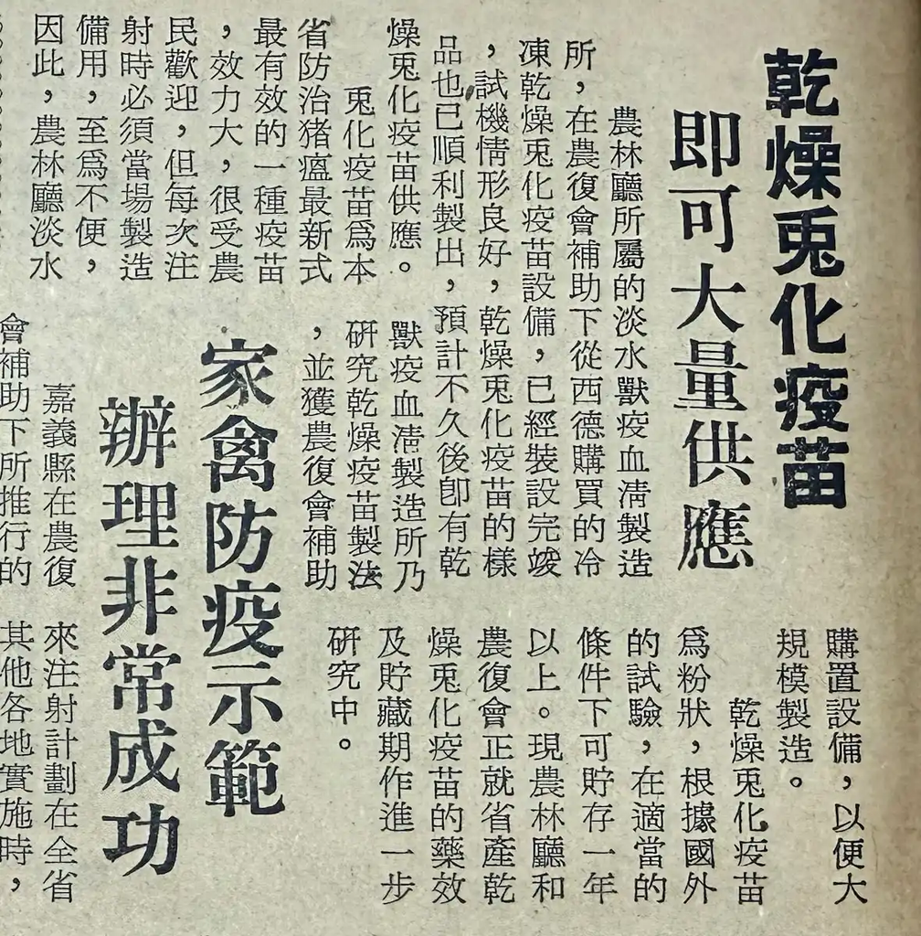

- **`Classical swine fever vaccine (兔化豬瘟疫苗)：`**
  - Serial passage (>800代): host adaptation
  - attenuation
  - phenotype drift

[傳統豬瘟疫苗見證防疫長路。](https://www.agriharvest.tw/archives/126252/)(圖片來源╱翻攝《豐年》第8卷第13期，1958年7月1日出版）

## 成功建立模型，不代表仍在回答原來的問題

- 兔化豬瘟疫苗成功協助控制重大動物傳染病
- 經過 host adaptation 的病毒，還能代表原本 PaBV biology 嗎？
  - virulence 是否改變？
  - tissue tropism 是否改變？
  - immune response 是否改變？
  - passage history 是否成為新的實驗變因？

## Cell model 能把 Replacement 推進到哪裡？

### 可以回答

- virus isolation/propagation
- infectious titer
- persistent cellular infection
- preliminary mechanism
- intervention screening

### 無法完整回答

- whole-animal susceptibility
- neural cellular composition
- tissue-to-tissue spread
- immune–nervous-system interaction
- clinical disease

**Note**

**`目前仍缺乏廣泛使用的 psittacine cell lines、reference atlas 與 species-specific reagents。`**

## 為什麼這個問題仍需要鸚鵡？

> PaBV genotype 與 psittacine nervous-tissue response 有何關係？

目前可以拿到的結果是：

1. 沒有其他可用實驗動物感染模型 (例如 mouse)
2. heterologous cells 只能回答 cell-level questions (例如 QM7 cell)
3. nervous-tissue response 需要保留 host、tissue context 與時間

因此，whole-animal psittacine model 仍提供不可替代的資訊。

## 不可替代，不代表可以降低設計標準

使用稀少、飼養困難且負擔較高的動物時，必須同時注意：

1. 問題值得回答
2. 替代模型不足
3. 實驗設計能產生可解釋資訊
4. 每隻動物的組織與所獲得的資料能被充分利用
5. 結論不超過 design 與 follow-up 的能力

## 我們的 PaBV animal experiment 案例

[figure not shown]

**Important**

這是一個 **small-n、28-day exploratory early-response study**，不是完整 disease-course study。

Study design based on the current manuscript Methods and Figure 2a.

## PaBV 的時間尺度不是單一終點，其他人怎麼做？

[figure not shown]

**Important**

追蹤時間決定能回答的 endpoint；增加 assays 不能補回缺少的時間。

Gancz et al. *Virol J*. 2009;6:100. [doi:10.1186/1743-422X-6-100](https://doi.org/10.1186/1743-422X-6-100)  
Leal de Araujo et al. *PLoS ONE*. 2017;12:e0187797. [doi:10.1371/journal.pone.0187797](https://doi.org/10.1371/journal.pone.0187797)  
Gartner et al. *Avian Pathol*. 2021;50:138–150. [doi:10.1080/03079457.2020.1852177](https://doi.org/10.1080/03079457.2020.1852177)

## Literature review: 投入資源換到了什麼資訊

| 研究策略 | 主要取得的資訊 | 主要代價/ 限制 |
| --- | --- | --- |
| **長期追蹤** | • viral shedding • seroconversion • clinical course • attrition | • 長期飼養負擔高 • 若採樣稀疏，延長時間未必增加有效資訊 |
| **分期犧牲取樣** | • 病毒與病變在組織間的先後順序 • 不同疾病階段的pathology | • 每隻動物只能提供一個terminal time point • 每個時間點都需要足夠的animal replication |
| **短期密集分析** | • early tissue response • cellular composition • mechanistic detail | • 無法回答chronic persistence • 無法觀察late clinical disease |
| **重複非侵入性採樣** | • individual trajectory • onset與intermittent change | • 可測量的endpoint有限 • 重複操作仍可能造成動物負擔 |

**Important**

**追蹤多久、何時採樣、分析多深，決定研究最後能回答什麼。**

## 理想的長期設計，遇到台北的現實

長期飼養 cockatiels 需要：

- 隔離空間與 biosecurity
- 穩定的溫濕度與環境控制
- 長期 animal-care 人力
  - 小鳥胃
  - 小鳥依人
- 噪音、粉塵與動物設施管理
- 可持續的經費與 contingency plan
  - 飼料
  - 營養品

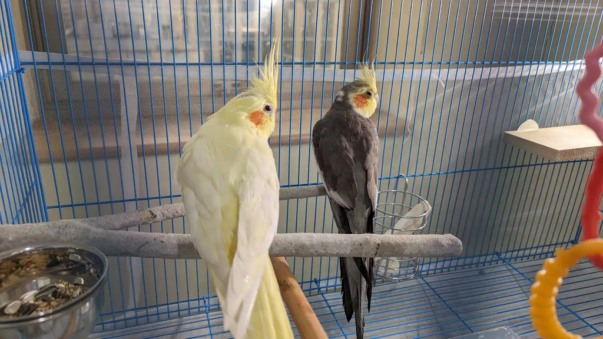

- 長期的 100–200 天實驗，未必能直接移植到現有環境。

## 28 days：不是較差的 200-day study

| 28-day design 可以支持 | 不能充分支持 |
| --- | --- |
| early tissue response | complete disease course |
| early neuropathological change | chronic persistence/carrier state |
| exploratory genotype-associated patterns | long-term shedding |
| tissue-processing feasibility | late GI pathology |
| early cellular remodeling | clinical incidence/survival |

**Important**

縮短 follow-up 必須同步縮小研究問題，而不是只縮短 protocol。

## 研究問題要符合實驗觀察的範圍

### **`超出設計能力`**

- PaBV-4與PaBV-5是否會造成不同的疾病？
  - 完整疾病發展
  - long-term shedding與persistence
  - clinical outcomes
  - 足夠的animal-level replication

### **`目前設計可探索`**

- 在觀察期之內，PaBV-4與PaBV-5是否呈現不同的early nervous-tissue responses？

目前設計明確限定：

- **時間：** 28 dpi
- **endpoint：** nervous-tissue response
- **研究定位：** exploratory comparison

**Important**

**研究問題、觀察時間、endpoint 與結論範圍必須一致。**

## Paper design check 1｜這個實驗做了什麼？

### 2009 PaBV-4 challenge study

**Animals**infected `n = 3`  
control `n = 2`

**Exposure**PaBV-4 brain homogenate

**Routes**IM, ocular, nasal, oral

**Follow-up**95 dpi

**Bias control**random assignment; blinded observer

**Welfare**predefined humane endpoint

**PAPER FIGURE｜Gancz et al., 2009**

[figure not shown]

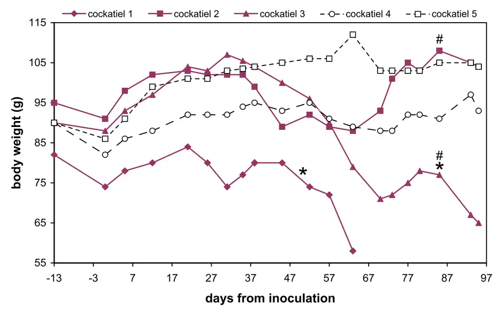

Gancz AY, et al. *Virology Journal*. 2009;6:100. [doi:10.1186/1743-422X-6-100](https://doi.org/10.1186/1743-422X-6-100)

## Paper design check 1｜小樣本能回答哪些問題？

### 可以支持

**Challenge 可建立 infection**接種後偵測到 PaBV infection

**感染動物出現 PDD 相關病變**clinical / pathological findings 與 control 不同

**支持因果推進**從 association 往 experimental causal evidence 前進

### 不能穩定估計

**disease incidence**`2/3` 是觀察結果，不是穩定發生率

**route effect**同一隻動物接受 multiple inoculation routes

**genotype / population risk**只有 PaBV-4，且樣本數太小

**Important**

**小樣本仍可提供因果證據，但不適合精確估計發生率或族群差異。**

Gancz AY, et al. *Virology Journal*. 2009;6:100. [doi:10.1186/1743-422X-6-100](https://doi.org/10.1186/1743-422X-6-100)

## Paper design check 2｜實驗開始前，各組真的可比較嗎？

### 2011 PaBV-2 challenge study

**Animals**challenged `n = 2`  
control `n = 1`

**Baseline**challenged birds 原本已 intermittently shedding PaBV-4

**Housing**control 位於另一獨立 aviary

- treatment 前各組是否在同一基線上？
- baseline 與 housing 若不同，結果就不能只歸因於 PaBV-2 challenge。

**PAPER EXCERPT｜Mirhosseini et al., 2011**

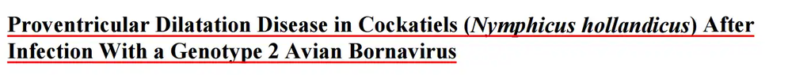

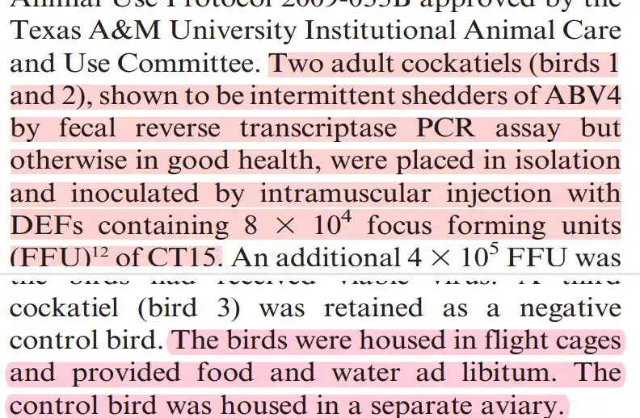

Mirhosseini N, et al. *Journal of Avian Medicine and Surgery*. 2011;25:199–204. [doi:10.1647/2010-030.1](https://doi.org/10.1647/2010-030.1)

## Paper design check 3｜總動物數不等於每個時間點的重複數

### 2017 PaBV-2 time-course study

**Total animals**34 cockatiels

**Design**serial sacrifice

**Time points**5–114 dpi，共 12 個

**Measurements**multi-tissue RT-PCR、histology、IHC

- 先判斷：每個時間點有幾隻動物？
- serial sacrifice 可提高時間解析度，但每隻動物只能代表當下時間點。

**PAPER FIGURE｜Leal de Araujo et al., 2017**

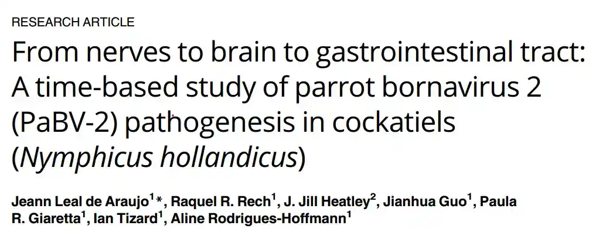

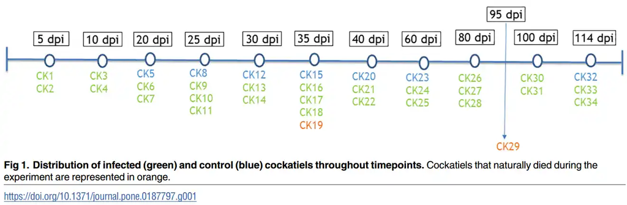

Leal de Araujo J, et al. *PLoS ONE*. 2017;12:e0187797. [doi:10.1371/journal.pone.0187797](https://doi.org/10.1371/journal.pone.0187797)

## 三個實驗、三種設計、回答不同問題

| Study | 主要回答的問題 | 設計提供的資訊 | 主要限制 |
| --- | --- | --- | --- |
| **2009 challenge** | PaBV exposure能否重現PDD相關病變？ | early causal/ proof-of-concept evidence | small `n`、multiple routes |
| **2011 challenge** | PaBV-2 challenge後會觀察到什麼？ | limited challenge observation | baseline infection、housing confounding |
| **2017 time course** | 病毒與病變如何隨時間進入不同組織？ | temporal與tissue distribution | replication分散至多個time points |

**Important**

**評估動物實驗時，先了解想要回答什麼，再判斷實驗設計能支持多大的結論。**

## ☕ 休息

**10 minutes**

# Part 3｜提高每隻動物的有效資訊

## 從「不可替代」走向「充分利用」

當鸚鵡活體模型仍不可替代時，減量（Reduction）不只是減少動物數：

1. 先定義真正要回答的研究終點
2. 讓不同資料形成同一條證據鏈
3. 保留樣本來源與相關資訊
4. 事先規畫組織分配
5. 避免產生無法解釋的大量資料

**Important**

重點不是每隻動物做更多檢測，而是讓每一項檢測共同回答同一個問題。

## 現代生醫研究可以看到多深？

[figure not shown]

**Important**

**`技術愈新、資料愈多，不代表研究問題回答得更好；關鍵是選擇適合的觀察層次。`**

Tang F, et al. *Nature Methods*. 2009;6:377–382. [doi:10.1038/nmeth.1315](https://doi.org/10.1038/nmeth.1315)  
Ståhl PL, et al. *Science*. 2016;353:78–82. [doi:10.1126/science.aaf2403](https://doi.org/10.1126/science.aaf2403)

## 為什麼組織病理之後還需要 scRNA-seq？

### 組織病理/IHC 可以回答

- 是否出現組織病變
- 病變位於哪些區域
- 特定標記的位置與細胞形態
- 不同證據在組織層次是否一致

### scRNA-seq 進一步探索

- 哪些細胞族群值得關注
- 細胞組成與細胞狀態可能如何改變
- 混合的組織訊號來自哪些細胞
- 後續需要驗證的候選生物路徑

**Important**

**`scRNA-seq 增加的是細胞層次的解析能力，不會自動增加獨立動物數。`**

## 從組織病變到細胞層級：中間缺了什麼？

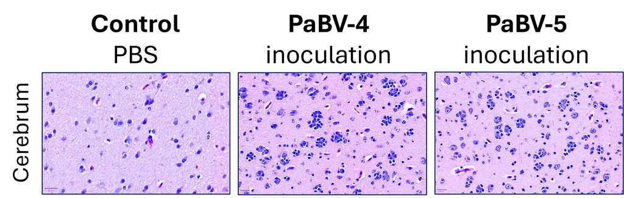

**`神經組織中出現膠質細胞增生 (gliosis)、神經元退化或發炎變化`**

這些細胞是誰？ 在做什麼？

1. 特定細胞族群的數量改變
2. 原有細胞進入不同的活化狀態
3. 組織解離與採樣造成細胞組成差異

**Important**

**新的技術應該用來回答原本無法解決的問題，而不是單純增加資料量。**

代表性病理影像，來源：作者投稿中手稿。

## 從動物到基因轉錄體分析：數量增加，不代表獨立性增加

[figure not shown]

**Important**

**`接受不同病毒接種的是動物個體；細胞數與 UMI 再多，也不會增加動物層次的生物重複。`**

## 三個 scRNA-seq 基因庫是如何建立的？

[figure not shown]

**Important**

**`每隻動物先個別處理；確認細胞數與存活率後，才將同組細胞等比例混合。`**

## 為什麼選擇混合樣本？

### **`實際限制`**

- 神經組織解離後，存活細胞流失
- 單一動物回收的細胞量可能不足
- 基因庫試劑與定序經費有限

### **`當時希望保留`**

- Control、PaBV-4、PaBV-5 三個組別
- 每組都有足夠的細胞輸入量
- 三組都能完成 scRNA-seq 取得資料

**Important**

**`混合樣本是為了讓三個實驗組別都能完成分析，不會增加生物重複。`**

## 三個混合基因庫：結果可以解釋到哪一層？

### **`可以描述`**

- 三個基因庫的細胞組成差異
- 不同細胞族群的基因表現模式
- 值得後續驗證的細胞族群與候選路徑

### **`不能直接判斷`**

- 同組兩隻動物是否反應一致
- 動物個體間變異
- 觀察結果是否可推廣至其他動物
- PaBV 基因型的確認性效應

**Important**

**`可以比較三個混合基因庫的變化模式，但不能將數千個細胞視為數千個生物重複。`**

## 下一次如何兼顧成本與個體來源？

[figure not shown]

**Note**

**`技術選擇必須在動物使用前決定，因為它會改變樣本處理方式與可支持的結論。`**

Stoeckius M, et al. *Genome Biology*. 2018;19:224. [doi:10.1186/s13059-018-1603-1](https://doi.org/10.1186/s13059-018-1603-1)

## 組織分配規畫必須在解剖前完成

| 樣本 | 優先用途 | 可回答的問題 | 備援 |
| --- | --- | --- | --- |
| 大腦/小腦 | scRNA-seq | 細胞變化模式 | 冷凍組織 |
| 相鄰腦組織切片 | H&E/IHC | 病變與標記驗證 | 影像檔案 |
| 腸胃道/神經節 | 組織病理 | 其他組織是否受影響 | 分子檢測 |
| 拭子/血液 | 縱向檢測 | 感染變化歷程 | 生物資料庫 |

**Important**

**`主要研究終點優先；探索性多體學分析不能排擠必要的組織病理與驗證。`**

## 組織有限時，每一種保存方式都會排除其他用途

[figure not shown]

**Important**

組織分配應依主要研究終點與樣本保存條件決定，而不是平均切開。

## 縱向採樣：同一隻動物提供更多時間資訊

### 可以增加的資訊

- ⚖️ 體重與臨床變化
- 🎥 行為與活動表現
- 🧪 後鼻孔/泄殖腔拭子
- 🩸 限量採血

### 同時增加的負擔

- 捕捉與保定壓力
- 重複操作與恢復時間
- 社會互動受干擾
- 採樣量與頻率限制

**Important**

**`重複採樣具有 Reduction 潛力，但採樣頻率仍須由研究問題與動物福祉共同決定。`**

## Part 3 小結｜提高資訊量，不等於增加生物重複

1. **不同技術回答不同層次的問題**  
   組織病理保留組織脈絡；scRNA-seq 提供細胞層次解析。
2. **混合樣本可以解決實務限制，也會犧牲個體來源**  
   更多細胞與 UMI 可以提高解析能力，但不會增加動物個體層次的重複。
3. **提高資訊量必須從實驗前開始規畫**  
   基因庫策略、組織分配與縱向採樣，都會影響最後可以回答的問題。

**Important**

- **Reduction 不只是從每隻動物取得最多資料**
- **更重要的是取得足以回答研究問題、且可以正確解釋的資料**

# Part 4｜高維資料的推論界線

## 案例：先追蹤資料如何產生

[figure not shown]

**Important**

**`同一個數字，只有放回資料產生的層次，才知道能支持哪一種結論。`**

- 重點不是先找最大差異或最小的 *p*-value，而是判斷：
  - 這些數字可以描述什麼？不能直接推論什麼？

## 腦部不是單一細胞族群

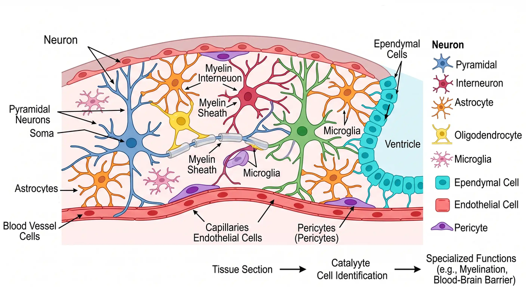

**Note**

同一塊神經組織中的變化，可能來自不同細胞族群比例改變，也可能來自特定細胞狀態改變。

AI生成示意圖；非真實資料。

## 從 UMAP 到細胞組成表

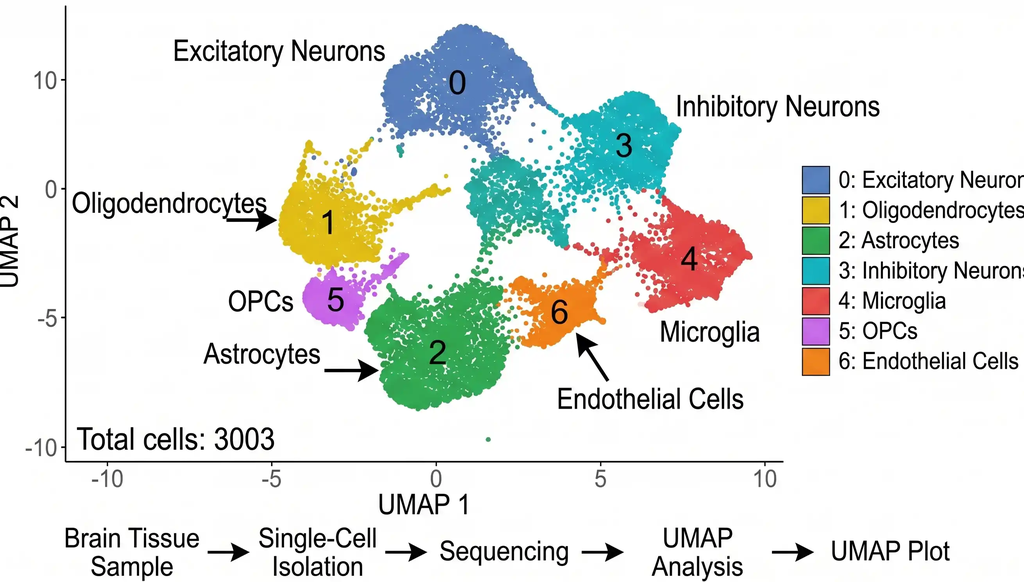

**Important**

UMAP 進行降維匯整將高維資料視覺化，但每個點仍然要放回原本的樣本來源解讀。

## 簡化的細胞組成表

| 細胞族群 | 對照組 | 處理組 |
| --- | --- | --- |
| Neuron-like cells | 62% | 48% |
| Astrocyte-like cells | 12% | 20% |
| Oligodendrocyte-like cells | 18% | 22% |
| Other cells | 8% | 10% |

**`適合`**：

- neuron-like cells 比例較低
- astrocyte-like cells 比例較高
- 其他細胞族群差異較小

**`不適合`**：

- 病毒造成神經元死亡
- astrocytes 明顯增生
- 動物個體間反應一致

**Important**

- 先描述混合基因庫中的差異
- 原因、機制與動物個體間一致性，則需要更多證據支持。

## 現在哪一句是適合的描述？

根據前一張混合樣本的細胞組成表：

- 處理造成神經元流失
- 處理促進星狀膠細胞增生
- 處理組與對照組的混合樣本呈現不同的細胞組成模式
- 所有接受處理的動物都有相同變化

## 從描述到推論：中間隔了幾層？

### **`可以描述`**

- 混合基因庫中的細胞比例不同
- 某些 cell populations 較高或較低
- 可作為後續驗證線索

### **`需要更多證據`**

- 是否代表細胞數真的增加或減少
- 是否與組織病變一致
- 是否出現在個別動物中
- 是否可由 IHC / histology 驗證

### **`不能直接跳到`**

- 病毒造成特定細胞死亡
- 所有感染動物都有相同反應
- genotype 具有族群層次效應
- 可推廣到完整疾病過程

**Important**

**高維資料可以提供線索，但「描述差異」、「解釋原因」與「推論到動物族群」是不同層次。**

## 從描述差異到統計比較

[figure not shown]

## 當 *p* < 0.05 時，回答的是哪一層問題？

若把數千個 cells 當成觀察值，*p*-value 可能非常小。

| 問題 | 是否能直接回答？ |
| --- | --- |
| 兩個混合基因庫中的 cell distribution / gene expression 是否不同？ | 可以 |
| 不同動物個體是否反應一致？ | 不行 |
| genotype 是否造成族群層次穩定差異？ | 不行 |

- **False discovery rate (FDR) correction**：用來控制多重檢定造成的假陽性；不是用來修正比較單位。

**Important**

**顯著的 *p*-value 仍然只能回答它所屬資料層次的問題。**

Zimmerman KD, et al. *Nature Communications*. 2021;12:738. [doi:10.1038/s41467-021-21038-1](https://doi.org/10.1038/s41467-021-21038-1)  
Squair JW, et al. *Nature Communications*. 2021;12:5692. [doi:10.1038/s41467-021-25960-2](https://doi.org/10.1038/s41467-021-25960-2)

## 判讀 *p*-value 前，先確認比較單位

假設兩個混合基因庫各有 `8,000` 個 cells：

| 比較單位 | 統計檢定看到的 n | *p*-value 能回答什麼？ |
| --- | --- | --- |
| **cell** | 8,000 vs 8,000 cells | 這份資料中的 cell-level 差異 |
| **基因庫** | 1 vs 1 mixed library | 無法估計組內變異 |
| **動物個體** | 個別來源已消失 | 無法估計 animal-to-animal variation |

判讀前先問：

1. 實驗處理發生在哪一層？
2. 哪些觀察值真正彼此獨立？
3. 統計檢定中的 `n` 代表什麼？

**Important**

統計計算可能正確，但如果比較單位不同，*p*-value 回答的問題也不同。

## 探索性資料的價值

即使不能直接支持動物族群層次的確認性結論，探索性資料仍可用來：

- 找出值得追蹤的 cell populations 或 pathways
- 指定後續 H&E / IHC / viral assay 的驗證目標
- 評估樣本處理與 scRNA-seq 流程是否可行
- 判斷下一次是否需要保留個別動物來源
- 協助規畫下一次的 endpoint、樣本數與檢測方法

**Important**

**`探索性資料的價值，不是替代生物重複，而是降低下一次實驗失敗的風險。`**

## 多層證據一致，可以增加可信度，但不會增加 n

| 證據來源 | 可以提供的支持 | 不能取代 |
| --- | --- | --- |
| **H&E** | 組織層次的病變 | 動物個體間重複 |
| **IHC** | 標記位置與細胞形態 | 定量推論本身 |
| **scRNA-seq** | 細胞族群與轉錄狀態線索 | animal-level replication |
| **病毒檢測** | 感染、組織分布或時間關聯 | 隨機分派與獨立樣本 |

**Important**

**多層證據一致可以增加生物學合理性；但不同檢測方法不是新的動物個體。**

## 設計能支持的解釋方式

### **`可以這樣寫`**

- 在這個案例中，不同混合基因庫呈現不同的細胞組成與轉錄變化模式。
- 這些變化可作為後續假說來源，並與 H&E、IHC 或病毒檢測結果進行對照。
- 由於個別動物來源未保留，是否能推廣到動物個體層次，仍需要具備 animal-level biological replication 的後續研究。

### **`避免這樣寫`**

- PaBV genotype 造成穩定的動物族群層次差異。

# Part 5｜理想與現實之間

## 先寫出理想設計，再加入現實限制

**`理想通常豐滿，現實往往骨感`**

**回答問題需要什麼：**

- 主要研究問題與主要研究終點
- 研究定位：探索性或確認性
- experimental unit 與 animal-level replication
- 個別動物、組織與基因庫的來源識別
- 追蹤時間、人道終點與預期脫落
- 隨機分派、盲目試驗、飼養空間與處理順序
- 組織分配、檢測優先順序與分析計畫

**Important**

**現實限制應該在設計階段改變研究問題，而不是在實驗完成後才拿來解釋不足。**

## 回顧目前的實驗，同時遇到哪些限制？

| 現實限制 | 直接影響 | 必須重新決定 |
| --- | --- | --- |
| 只有 6 隻動物可用 | animal-level replication 很低 | 保留三組探索性比較，或減少比較組別 |
| 只能負擔 3 個 scRNA-seq 基因庫 | 個體來源識別受限 | 混合樣本、multiplexing 或分階段設計 |
| 最長追蹤 28 天 | 無法推論完整疾病歷程 | 偵測早期感染反應 |
| 只有 3 個飼養空間 | 飼養空間可能與處理組別混淆 | 重新規畫分配、批次與飼養策略 |
| 組織有限 | 病理、PCR、IHC、scRNA-seq 互相競爭 | 主要研究終點優先 |
| 可能有動物淘汰 | 最終可分析的 n 下降 | 預留數量並設定繼續/停止條件 |

## 合理調整的幾種可行方向

1. 增加資源或跨單位合作
2. 縮小研究問題與結論層次
3. 改成先導試驗或可行性試驗
4. 減少實驗組別或次要研究終點
5. 分階段進行，先驗證最不確定的環節
6. 暫不執行

**Important**

**若目前設計無法回答問題，暫緩執行也是最負責任的減量 (Reduction)。**

## 把受限制的折衷留下紀錄

| 項目 | 現實限制 | 最後選擇 | 結論影響 |
| --- | --- | --- | --- |
| **動物數** | 可用動物有限 | 定位為先導試驗 | 不做確認性結論 |
| **scRNA-seq** | 基因庫數有限 | 同組混合或 multiplexing | 限縮個體層次推論 |
| **追蹤時間** | 最長 28 天 | 聚焦早期研究終點 | 不談完整疾病歷程 |
| **組織分配** | 樣本有限 | 病理與病毒檢測優先 | 次要分析定位為探索性 |
| **飼養條件** | 隔離空間有限 | 明確記錄並盡量平衡 | 若無法分離，結論需保守 |

**Note**

**每一個折衷都要有能對應最後能支持的結論。**

## 在限制下，設計要怎麼改？

6 隻動物 3 個隔離飼養空間 3 scRNA-seq 基因庫 28 天追蹤 病理、PCR、IHC、scRNA-seq 都想做

**1**保留哪一個主要研究問題？

**2**犧牲了哪一層推論？

**3**如何避免飼養空間與處理條件混淆？

**4**哪些結論必須降級為探索性？

**Important**

**`重新設計不是把檢測塞滿，而是讓問題、設計與結論重新對齊。`**

## 如何檢視一個重新設計方案？

不論方案由誰提出，只檢查四件事：

1. 主要研究問題是否已經縮小？
2. experimental unit 與真正的重複數在哪裡？
3. 飼養空間、批次或操作人員是否與處理條件混淆？
4. 結論是否超過追蹤時間與樣本來源識別？

**Note**

**`好的檢視不是提出更多檢測方法，而是指出哪一項設計決策會改變推論。`**

## 選擇取決於研究目的，沒有單一最佳方案

**探索性先導試驗***適合回答*Control、PaBV-4、PaBV-5 的早期變化全貌*必須承認***不做 animal-level 確認性結論**

**對照組 vs 單一基因型***適合回答*感染與對照之間較穩定的個體層次差異*必須承認***不能直接比較 PaBV-4 與 PaBV-5**

**分階段設計***適合回答*先確認感染、採樣與檢測流程是否可行*必須承認***完成時間較長，第一階段結論較小**

可再搭配：

- multiplexing（多重標記）
- 縱向非侵入性採樣
- 跨單位合作

## EDA：把實驗設計畫成可檢查的計畫

**`NC3Rs Experimental Design Assistant (EDA)`** 協助研究者圖形化設計決策檢查。

**畫出實驗流程**stepwise visual representation

**檢查設計風險**bias、變異來源、experimental unit

**支援事前規畫**randomisation、blinding、sample size

[figure not shown]

Scan QR or visit: [eda.nc3rs.org.uk](https://eda.nc3rs.org.uk/)

**Important**

**EDA 不是替研究者決定答案，而是讓設計決策被明確畫出來以進行檢查以及討論。**

NC3Rs. Experimental Design Assistant. [nc3rs.org.uk](https://nc3rs.org.uk/our-portfolio/experimental-design-assistant-eda)

## PREPARE：在動物使用前完成跨角色規畫

[figure not shown]

**研究問題與模型**動物模型、主要研究終點、組織分配圖

**執行與容量**動物數、飼養條件、隨機分派、樣本處理與平台容量

**福祉與紀錄**人道終點、繼續/停止條件、原始資料與分組紀錄

Smith AJ, et al. *Laboratory Animals*. 2018;52:135–141. [doi:10.1177/0023677217724823](https://doi.org/10.1177/0023677217724823)

# Part 6｜執行與紀錄：讓設計真正成立

## 好設計也可能在執行中失效

- 分組紀錄遺失
- 處理順序固定，與組別混淆
- 操作人員固定，與處理條件混淆
- 組織處理時間拖太長
- 執行流程逐漸偏離原計畫
- 原始資料與動物相關資訊無法追溯

## 當實驗複雜時，可能變成混淆因素

**如果同一天處理三組腦組織樣本：**

1. 一隻動物的犧牲及採樣大約 30 分鐘
   - 60 分鐘 / 組
   - 三組 = 180 分鐘

**若細胞存活率隨處理時間下降：**

1. 基因型效應與處理順序效應將無法分離。
2. 細胞品質無法符合後續實驗的需求！

**`應對方式：`**

- 平衡或隨機安排處理順序
- 每一批盡量包含不同實驗組別
- 記錄採樣到開始處理的時間
- 在分析與結果解釋中保留批次資訊

## 隨機分派與盲目試驗要留下可稽核紀錄

### 隨機分派

- 分派方法與亂數種子
- 分層或區集變項
- 分組表
- 籠位與房間位置
- 處理順序

### 盲目試驗

- 臨床評分
- 組織病理評分
- 影像選取
- 樣本排除決策
- 檔案編碼與資料分析

盲目試驗以分階段設計，不是全有或全無。

Percie du Sert N, et al. *PLoS Biology*. 2020;18:e3000410. [doi:10.1371/journal.pbio.3000410](https://doi.org/10.1371/journal.pbio.3000410)

## 偏離計畫：要能回到動物與樣本

### 偏離事件要記清楚

**發生什麼？**例如處理延遲、樣本污染、記錄漏失

**何時發生？**採樣、處理、建庫、影像或分析階段

**影響哪些動物與樣本？**不要只寫「某一批」或「部分樣本」

**是否改變分析條件？**納入、排除或改變解釋層次

### 資料來源要串得回去

動物 ID 籠位 / 房間 處理條件 樣本 ID 基因庫 / 影像 分析輸出

**Important**

公開資料可以去識別化；研究團隊內部不能切斷 linkage key。

## 這個案例如何回到 3R？

| 3R | 本案例中的實際意義 |
| --- | --- |
| **Replacement** | 先評估小鼠與細胞模型，並說明適用邊界 |
| **Reduction** | 聚焦研究問題、提高有效資訊、分階段設計與資料再利用 |
| **Refinement** | 改善飼養條件、保定操作、採樣負擔與人道終點 |

**Note**

**Refinement 不是把研究「做得更精緻」，而是減少動物的疼痛、緊迫與不必要負擔。**

## 從鸚鵡延伸到其他非模式動物

可能包括：

- 鴿子的腫瘤影像研究
- 斑胸草雀的聲音與社會行為
- 野生動物追蹤
- 動物園與保育醫學

提醒：

> 影像、聲音、時間點或細胞可以很多，但真正彼此獨立的動物可能很少。

## 動物實驗的前中後檢查

### `開始前：設計先寫清楚`

- 動物模型、研究問題、實驗單位與主要研究終點已定義
- 動物數、飼養條件、隨機分派與組織分配圖已完成
- 排除條件與偏離計畫紀錄方式已先寫好

### `執行中：紀錄要串得回去`

- 持續記錄動物福祉、偏離計畫、處理順序與樣本來源
- 保留動物、樣本、檔案與分析輸出的 linkage

### `解釋時：結論不要超過設計`

- 已揭露混合樣本、動物脫落與遺漏資料
- 探索性與確認性結論分開
- 推論沒有超過設計能力

## 最後一題

哪一句最準確？

- 只要使用 scRNA-seq，就能以較少動物完成確認性研究
- 極小的 p-value 可以補足 biological replication
- 高資訊量設計有助於 Reduction，但不能改變 experimental unit
- 預算不足時，應優先刪除對照組

## References｜PaBV experimental infection

- Gancz AY, et al. *Virology Journal*. 2009;6:100. doi:10.1186/1743-422X-6-100.
- Mirhosseini N, et al. *Journal of Avian Medicine and Surgery*. 2011;25:199–204. doi:10.1647/2010-030.1.
- Leal de Araujo J, et al. *PLoS ONE*. 2017;12:e0187797. doi:10.1371/journal.pone.0187797.
- Gartner AM, et al. *Avian Pathology*. 2021;50:138–150. doi:10.1080/03079457.2020.1852177.
- Rubbenstroth D. *Viruses*. 2022;14:1513. doi:10.3390/v14071513.

## References｜design and reporting

- Smith AJ, et al. PREPARE guidelines. *Laboratory Animals*. 2018;52:135–141. doi:10.1177/0023677217724823.
- Percie du Sert N, et al. ARRIVE guidelines 2.0. *PLoS Biology*. 2020;18:e3000410. doi:10.1371/journal.pbio.3000410.
- Zimmerman KD, et al. *Nature Communications*. 2021;12:738. doi:10.1038/s41467-021-21038-1.
- Squair JW, et al. *Nature Communications*. 2021;12:5692. doi:10.1038/s41467-021-25960-2.
- Stoeckius M, et al. *Genome Biology*. 2018;19:224. doi:10.1186/s13059-018-1603-1.
- NC3Rs. Experimental Design Assistant. https://nc3rs.org.uk/our-portfolio/experimental-design-assistant-eda

## Thank you

**Discussions**